# CHAPTER A 14

# 曲げせん断応力 - 実心および開断面

# せん断中心

## A14.1 はじめに

第A6章では、純粋なねじり力を受ける部材内のせん断応力について詳細に検討した。第A13章では、純粋な曲げを受ける梁の曲げ応力についてかなり詳しく検討した。しかし、実際の構造物においては、純粋な曲げ力（偶力）が梁に作用する荷重となることはめったにない。通常の場合、梁に作用する曲げモーメントは外力としてのせん断力の伝達によるものである。したがって、梁の曲げには通常、曲げ（軸方向の引張応力および圧縮応力）とせん断応力の両方が伴う。

曲げ応力の式を導出する際に第A13章で行われたものと同じ仮定が、たわみせん断応力の式を導出する際にも同様に使用される。たわみせん断応力が存在する場合、梁が曲がるときにせん断ひずみによって梁の断面がその平面からわずかに反るため、曲げた後も平面断面が平面のままであるという仮定は完全には成り立たない。この反り作用は通常、「せん断遅れ（shear lag）」という用語で呼ばれる。しかし、幅が広く薄いフランジを持つ梁の場合を除いて、せん断ひずみを無視することによって導入される誤差は非常に小さいため、基本的なたわみせん断応力公式を導出する際には無視される。せん断遅れの影響の問題は、他の章で検討される。

## A14.2 せん断中心

いくつかの外荷重系により、梁がねじれることなく曲がるとき、梁の横断面にせん断応力が発生する。この内部せん断力系の図心は、その特定の断面のせん断中心と呼ばれることが多い。断面のねじれを防ぐためには、この断面における合外せん断荷重が断面のせん断中心を通過しなければならない。したがって、せん断中心が分かっていれば、外荷重の影響を、一方はたわみを引き起こし、他方はねじりのみを引き起こす2つの系統で表すことができる。

## A14.3 たわみせん断応力公式の導出

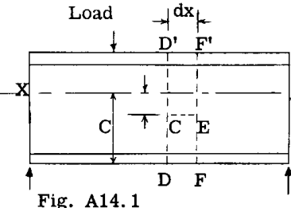

Fig. A14.1

図 A14.1は、荷重を受けた単純支持梁を示している。与えられた荷重によって梁が下方に曲がるとき、中立軸より上の梁部分は圧縮状態になり、中立軸より下の部分は引張状態になる。梁上の点D、Fにおける梁の短い部分 $dx$ を考え、図 A14.3に示すようにフリーボディとして扱う。梁部分の各面に作用する引張応力および圧縮応力の変化は、示されている通りである。

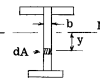

Fig. A14.2

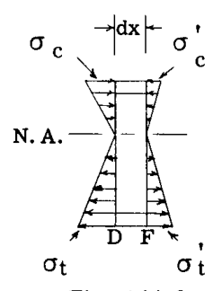

Fig. A14.3

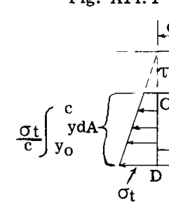

Fig. A14.4

応力 $\sigma_t$ は $\sigma'_t$ より大きい。なぜなら、与えられた梁の荷重による曲げモーメントが、梁の断面 FF’ におけるよりも断面 DD’ において大きいためである。ここで、この梁部分 $dx$ が、図 A14.1の切欠き DCEF で示されるようにさらに切り取られ、このセグメントが、示されているような力を伴うフリーボディとして図 A14.4に示されていると考える。

$\sigma_t$ を中立軸から距離 $c$ における最大引張応力とする。

このとき、中立軸から距離 $y$ における応力は、 $\sigma_y = \sigma_t \frac{y}{c}$ である。

したがって、梁断面の微小面積 $dA$ （図 A14.2参照）における全荷重は、 $\frac{\sigma_t}{c} y dA$ に等しい。

ここで、図 A14.4を参照して、このセグメントの各面に作用する全引張荷重を計算する。

$$\text{面 CD 上の全荷重} = \frac{\sigma_t}{c} \int_{y_0}^{c} y dA \quad \text{--- (1)}$$

$$\text{面 FE 上の全荷重} = \frac{\sigma'_t}{c} \int_{y_0}^{c} y dA \quad \text{--- (2)}$$

第A13章から、たわみ応力 $\sigma$ の式、すなわち $\sigma_t = \frac{Mc}{I}$ が導出された。 $M$ を梁断面 DD’ における曲げモーメントとし、 $M'$ を梁断面 FF’ における曲げモーメントとする。また、 $I$ および $I'$ をそれぞれ、これらの同じ梁断面における中立軸まわりの断面積の慣性モーメントとする。そして、式(1)および(2)に $\sigma_t$ の値を代入すると、次のように書くことができる。

$$\text{面 CD 上の全荷重} = \frac{M}{I} \int_{y_0}^{c} y dA \quad \text{--- (3)}$$

$$\text{合水平荷重} = \frac{M - M'}{I} \int_{y_0}^{c} y dA$$

x-x 方向のセグメントの平衡について、

$$\Sigma F_x = - \frac{M - M'}{I} \int_{y_0}^{c} y dA + \tau b dx = 0$$

したがって、

$$\tau = \frac{M - M'}{I b dx} \int_{y_0}^{c} y dA \quad \text{--- (5)}$$

しかし、

$$\frac{M - M'}{dx} = \frac{dM}{dx} = V = \text{梁断面における外力せん断力}$$

したがって、

$$\tau = \frac{V}{I b} \int_{y_0}^{c} y dA \quad \text{--- (6)}$$

式(6)は、等断面の梁（慣性モーメントが一定）にのみ適用されることに注意することが重要である。飛行機の翼構造では、梁の断面や慣性モーメントが変化するのが一般的であり、この変化が著しい場合には、式(6)を使用すべきではなく、式(3)および(4)に頼るべきである。この事実は、例題2で説明されている。この可変断面の問題については、本章の後半で説明する。

## A14.4 例題。対称断面。外らせん荷重がせん断中心を通過する場合。

### 例題 1

図 A14.5は、Y-Y 軸に対して対称な梁の断面を示している。この断面を持つ梁が、Y 方向のせん断荷重 $V_y = 850\text{ lb}$ を生じる荷重を受けると仮定する。その位置は、この軸に対する断面の対称性のために、梁断面の図心 y 軸上にある断面のせん断中心を通る。図 A14.5に示すように、中立軸 x-x および断面の点 1-1、2-2 におけるせん断応力を求めることが求められている。中立軸の位置およびこの軸まわりの断面の慣性モーメントは図に示されている。

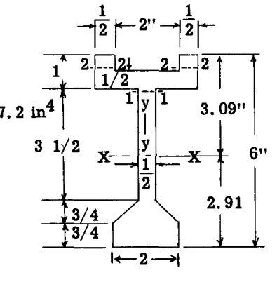

Fig. A14.5

### 解答

中立軸 x-x におけるせん断応力

$$\tau_{x-x} = \frac{V_y}{I_x b} \int_{0}^{3.09} y dA$$

表 A は、 $\int_{0}^{3.09} y dA$ の項の計算を示している。

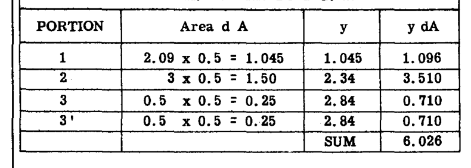

TABLE A

したがって、

$$\tau = \frac{850 \times 6.026}{27.2 \times 0.5} = 377\text{ psi.}$$

点 1-1 におけるせん断応力の計算：

$$\tau_{1-1} = \frac{V_y}{I_x b} \int_{2.09}^{3.09} y dA$$

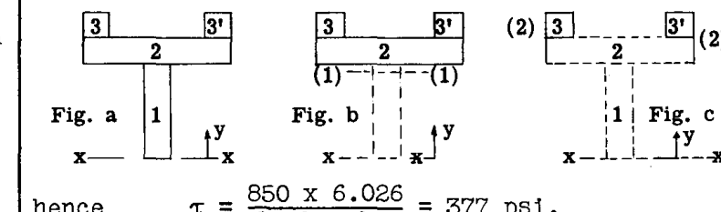

Fig. a, Fig. b, Fig. c

図 b はこの積分における有効面積を示している。したがって、表 A において部分 1 を除外するため、 $\int y dA = 4.93$ となる。

代入すると、

$$\tau_{1-1} = \frac{850 \times 4.93}{27.2 \times 0.5} = 308\text{ psi.}$$

断面の点 2-2 におけるせん断応力：

図 c は有効面積を示している。したがって、表 A において部分(1)および(2)は除外され、

$$\int_{2.59}^{3.09} y dA = 1.42$$

となる。

代入すると、

$$\tau_{2-2} = \frac{850 \times 1.42}{27.2 \times 1.0} = 44.4\text{ psi.}$$

（2つの部分 3, 3’ の幅 $b = 0.5 + 0.5$ ）。

計算されたせん断応力は、Y 方向の梁断面の平面内に作用し、また、梁断面に垂直な Z 軸に平行な同じ強さで作用する。

### 例題 2. 可変慣性モーメント。

図 A14.6は、端部に $600\text{ lb}$ の単一荷重が作用し、梁断面の図心を通過する片持ち梁を示している。梁の断面はステーション 0 と 132 の間で一定であり、その後、ステーション 175 および 218 に示される断面へと一様にテーパーしている。ステーション 175 および 218 における梁断面上のせん断応力分布を決定する。

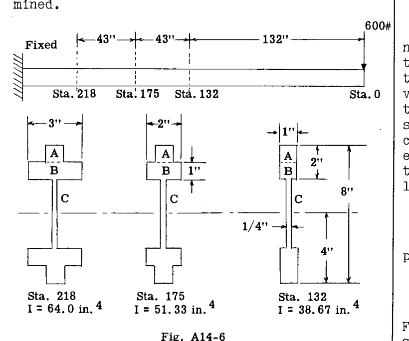

Fig. A14.6

### 解答

曲げモーメント：

$$\begin{aligned}
M_{132} &= -600 \times 132 = -79,200\text{ "\#} \\
M_{175} &= -600 \times 175 = -105,000\text{ "\#} \\
M_{218} &= -600 \times 218 = -130,800\text{ "\#}
\end{aligned}$$

表 A14.1は、3つのステーションについて中立軸の各側における3つの点での曲げ応力を計算した結果を示している。例えば、ステーション 132 の場合、

$$\sigma_{\text{MAX}} = \pm \left( \frac{M c}{I} \right) = \pm \left( \frac{79200 \times 4}{38.67} \right) = \pm 8180\text{ psi.}$$

（上縁で引張、下縁で圧縮）。

梁のいずれかの縁から1インチの点について、

$$\sigma = \pm \left( \frac{79200 \times 3}{38.67} \right) = \pm 6135\text{ psi.}$$

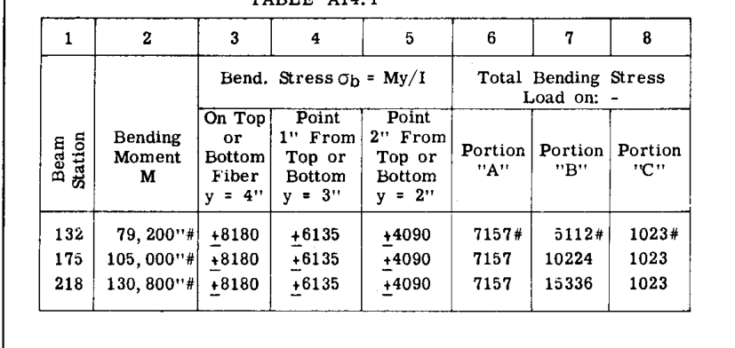

TABLE A14.1

表 A14.1の結果から、3つのステーション間における慣性モーメントの変化は、曲げモーメントの変化に直接比例しているため、3つのステーションすべてにおいて曲げ応力に対して同じ値になることに注目すべきである。列 6, 7, 8 は、3つの断面の部分 A, B, C における全曲げ応力荷重を示している（図 A14.6参照）。これらの値は、部分の平均応力に部分の面積を掛けたものに等しい。例えば、ステーション 132 の場合、部分 A 上の荷重は、

$$\text{荷重} = \frac{8180 + 6135}{2} \times 1 \times 1 = 7157\text{ \#,}$$

であり、部分 C の場合は、

$$\text{荷重} = \frac{4090 + 0}{2} \times 2 \times .25 = 1023\text{ \#}$$

となる。

図 A14.7は、ステーション 175 と 218 の間の梁の一部に作用する引張応力および圧縮応力を示している。

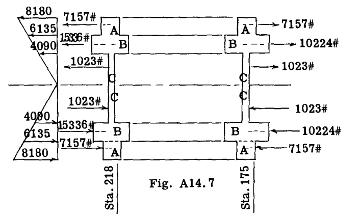

Fig. A14.7

図 A14.8は、図 A14.7の荷重から生じる水平せん断応力パターンを示している。例えば、梁の上縁または下縁から1インチに沿って断面を取り、図 A14.12に示すようにこの部分をフリーボディとして扱い、 $\Sigma H = 0$ を適用すると、

$$\Sigma H = -7157 + 7157 + \tau \times 43 \times 1.0 = 0, \quad \text{したがって} \quad \tau = 0$$

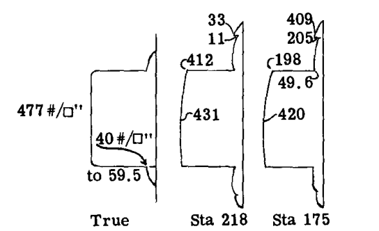

Fig. A14.8, Fig. A14.10, Fig. A14.9

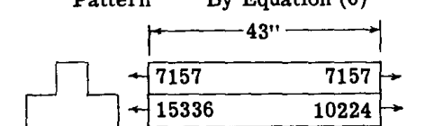

Fig. A14.13

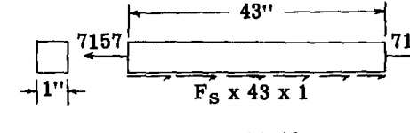

Fig. A14.12

同様に、梁の縁と縁から2インチの点の間の部分を図 A14.13に示すようなフリーボディ図として扱うと、

$$\Sigma H = -7157 + 7157 - 15336 + 10224 + \tau \times 43 \times .25 = 0, \quad \text{したがって} \quad \tau = 477\text{ psi.}$$

明らかに、部分 C におけるせん断応力は一定である。なぜなら、両方のステーションにおけるこの部分の端部荷重が同じ、すなわち $1023\text{ \#}$ であるからである。

図 A14.8は、ステーション 175 と 218 の間の任意の点における梁断面上のせん断応力分布の一般的な形状を示している。ステーション 132 と 175 の間のせん断応力は同じになる。なぜなら、曲げモーメントと慣性モーメントの変化が、ステーション 175 と 218 の間と同じになるように作られているからである。

図 A14.9および図 A14.10は、各ステーションに対して公式 $\tau = \frac{V \int y dA}{I b}$ が使用された場合のせん断応力パターンを示している。この式は変化する断面の梁には適用されないため、不一致はかなり大きい。

公式による計算を説明するために、ステーション 175 における梁断面の中立軸におけるせん断応力を計算する。

$$\tau = \frac{V}{I b} \left[ \int_{0}^{4} y dA \right]$$

ここで、

$$\int_{0}^{4} y dA = 1 \times 1 \times 3.5 + 2 \times 1 \times 2.5 + 2 \times 0.25 \times 1 = 9.0$$

したがって、

$$\tau = \frac{600 \times 9.0}{51.33 \times 0.25} = 420\text{ psi.}$$

となり、これは図 A14.8における 477 の真のせん断応力と比較される。

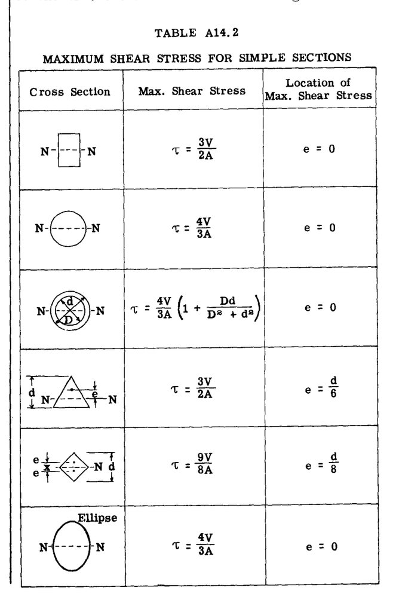

TABLE A14.2